# R Einführung - Wirkung von Insektensprays

Der Datensatz *InsectSprays* enthält Informationen über die Wirkung von sechs verschiedenen Insektensprays (A-F) auf verschiedene Insektenarten. Ursprünglich stammt der Datensatz aus einem Experiment, bei dem die ausgewählten Insektensprays zufällig auf verschiedene Insektengruppen aufgetragen wurden. Anschliessend wurden die Insekten beobachtet und die Anzahl der getöteten oder betäubten Insekten gezählt. Das Hauptziel des Datensatzes ist es, die Wirksamkeit verschiedener Insektizide bei der Bekämpfung von Insekten zu untersuchen. Dies kann für die Bewertung und Verbesserung von Insektiziden von Interesse sein.

## Frage 1: Datenüberblick

Laden Sie den InsectSprays-Datensatz.

```r
data(InsectSprays)
print('Daten geladen')
```

```
[1] "Daten geladen"
```

Zeigen Sie die ersten sechs Zeilen des Datensatzes an.

```r
head(InsectSprays)
```

A data.frame: 6 × 2

|  | count <dbl> | spray <fct> |
| --- | --- | --- |
| 1 | 10 | A |
| 2 | 7 | A |
| 3 | 20 | A |
| 4 | 14 | A |
| 5 | 14 | A |
| 6 | 12 | A |

Welche Variablen sind im Datensatz enthalten?

**Antwort:** Der Datensatz enthält zwei Hauptvariablen: "count" und "spray". Die "count"-Variable gibt die Anzahl der getöteten Insekten an, während "spray" die Art des verwendeten Insektensprays angibt. Es gibt sechs verschiedene Arten von Sprays: A, B, C, D, E und F.

## Frage 2: Deskriptive Statistik

Zeigen Sie eine statistische Zusammenfassung des Datensatzes an.

```r
summary(InsectSprays)
```

```
     count       spray
 Min.   : 0.00   A:12
 1st Qu.: 3.00   B:12
 Median : 7.00   C:12
 Mean   : 9.50   D:12
 3rd Qu.:14.25   E:12
 Max.   :26.00   F:12
```

Wie hoch ist die durchschnittliche Wirkung aller Insektensprays zusammen?

**Antwort:** Die durchschnittliche Wirkung aller Insektensprays zusammen beträgt etwa 9.5.

## Frage 3: Visualisierung

Ein Histogramm für die Anzahl der behandelten Insekten (count) erstellen.

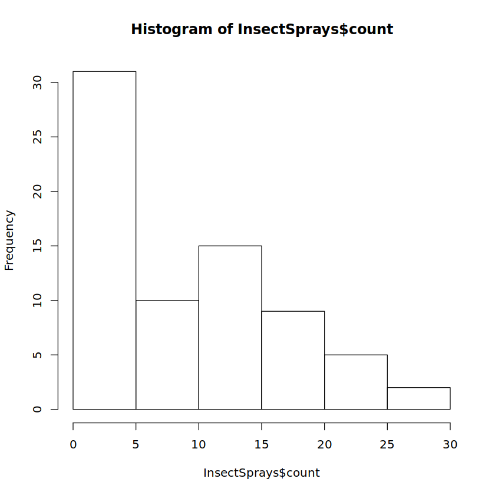

```r
hist(InsectSprays$count)
```

Welche Art der Verteilung ist zu erkennen?

**Antwort:** Rechtschiefe Verteilung

Erstellen Sie ein Balkendiagramm der durchschnittlichen Wirkung jedes Insektensprays.

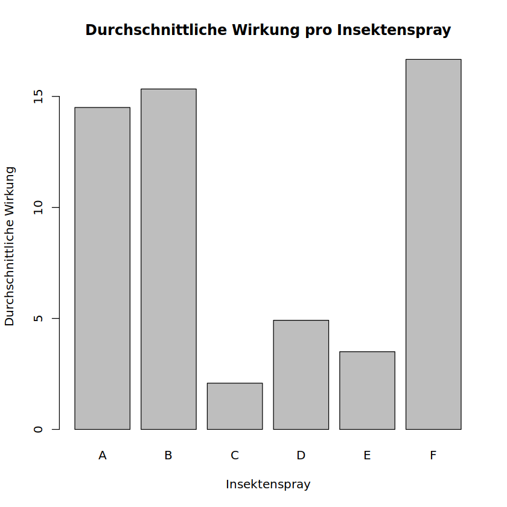

```r
barplot(tapply(InsectSprays$count, InsectSprays$spray, mean),
        main="Durchschnittliche Wirkung pro Insektenspray",
        xlab="Insektenspray", ylab="Durchschnittliche Wirkung")
```

Erstellen Sie ein Boxplot der Wirkungen der Insektensprays.

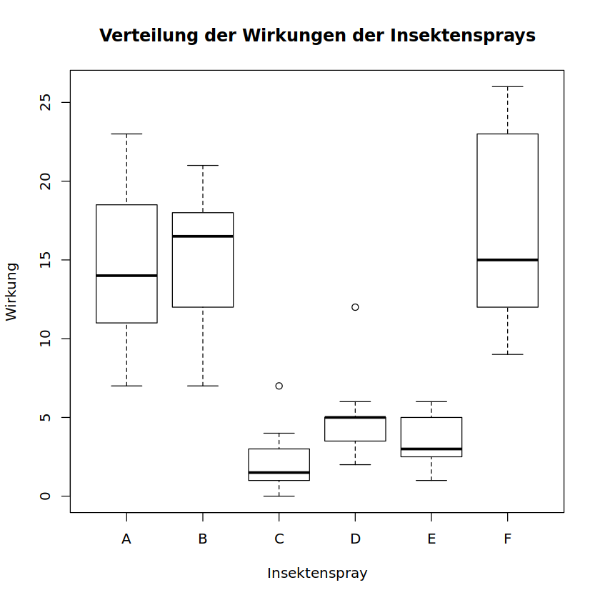

```r
boxplot(count ~ spray, data=InsectSprays,
        main="Verteilung der Wirkungen der Insektensprays",
        xlab="Insektenspray", ylab="Wirkung")
```

Welches Insektenspray hat die höchste durchschnittliche Wirkung?

**Antwort:** Das Insektenspray "sprayF" hat die höchste durchschnittliche Wirkung.

Welches Insektenspray hat die geringste durchschnittliche Wirkung?

**Antwort:** Das Insektenspray "sprayC" hat die geringste durchschnittliche Wirkung.

## Frage 4: Konditionaler Mittelwert

Berechnen Sie den Durchschnitt (Mittelwert) der Wirkung des Sprays "sprayB".

```r
mean_sprayB <- mean(InsectSprays$count[InsectSprays$spray == "B"])
print(mean_sprayB)
```

```
[1] 15.33333
```

Welchen Wert ergibt die Berechnung?

**Antwort:** Der Durchschnitt der Wirkung des Sprays "sprayB" beträgt etwa 15.3.

## Frage 5: Variabilität

Berechnen Sie die Standardabweichung der Wirkung des Sprays "sprayD".

```r
sd_sprayD <- sd(InsectSprays$count[InsectSprays$spray == "D"])
print(sd_sprayD)
```

```
[1] 2.503028
```

Wie viel Variation gibt es in den Wirkungen dieses Sprays?

**Antwort:** Die Standardabweichung der Wirkung des Sprays "sprayD" beträgt etwa 2.5.

## Frage 6: Korrelation

Berechnen Sie die Korrelation zwischen den Wirkungen der Sprays "sprayE" und "sprayF".

```r
cor_sprayE_F <- cor(InsectSprays$count[InsectSprays$spray == "E"], InsectSprays$count[InsectSprays$spray == "F"])
print(cor_sprayE_F)
```

[output not shown]

Gibt es eine positive oder negative Korrelation zwischen den Wirkungen?